# Student Performance Evaluation Analysis

## by Olusola Timothy Ogundepo

## Introduction

PISA is a survey of students skills and knowledge as they approach the end of compulsory education. It is not a conventional school test. Rather than examining how well students have learned the school curriculum, it looks at how well prepared they are for life beyond school. Around 510,000 students in 65 economies took part in the PISA 2012 assessment of reading, mathematics and science representing about 28 million 15-year-olds globally.

## Preliminary Wrangling

```python
# import all packages and set plots to be embedded inline
import numpy as np
import pandas as pd
import matplotlib.pyplot as plt
import seaborn as sb
from warnings import filterwarnings

filterwarnings('ignore')
plt.style.use('fivethirtyeight')
%matplotlib inline
```

```python
# Dict of all the needed columns
colnames = {
    "STIDSTD": "stud_id",
    "NC": "country",
    "ST04Q01": "gender",
    "ST05Q01": "pri_sch",
    "ST06Q01": "age_at_pri_sch",
    "ST01Q01": "intl_grade",
    "ST08Q01": "late_for_school",
    "ST09Q01": "skip_day",
    "ST115Q01": "skip_class",
    "ST26Q02": "possess_room",
    "ST26Q03": "possess_study_place",
    "ST26Q04": "possess_computer",
    "ST26Q06": "possess_internet",
    "ST26Q10": "possess_textbook",
    "ST29Q06": "math_interest",
    "ST42Q01": "math_anxiety",
    "MATBEH": "math_behaviour",
    "PV1MATH": "math_score",
    "PV1READ": "read_score",
    "PV1SCIE": "science_score",
    "ST44Q03": "failure_attr",
    "ST13Q01": "mother_sch_lvl",
    "ST17Q01": "father_sch_lvl",
    "ST15Q01": "mother_job_status",
    "ST19Q01": "father_job_status",
    "TCHBEHFA": "teacher_behaviour",
    "TEACHSUP": "teacher_support",
    "BFMJ2": "father_earning_pct",
    "BMMJ1": "mother_earning_pct"
}
```

```python
# Loading the pisa dataset
pisa_df = pd.read_csv('pisa2012/pisa2012.csv', encoding='ANSI', nrows=2e5, usecols=colnames.keys(), low_memory=False)
```

```python
pisa_df.info()
```

```
<class 'pandas.core.frame.DataFrame'>
RangeIndex: 200000 entries, 0 to 199999
Data columns (total 29 columns):
 #   Column    Non-Null Count   Dtype
---  ------    --------------   -----
 0   NC        200000 non-null  object
 1   STIDSTD   200000 non-null  int64
 2   ST01Q01   200000 non-null  int64
 3   ST04Q01   200000 non-null  object
 4   ST05Q01   194537 non-null  object
 5   ST06Q01   184727 non-null  float64
 6   ST08Q01   196367 non-null  object
 7   ST09Q01   196385 non-null  object
 8   ST115Q01  196481 non-null  float64
 9   ST13Q01   186541 non-null  object
```

[output cut: 21 more lines]

```python
# Top 5 rows of the dataset
pisa_df.head()
```

|  | NC | STIDSTD | ST01Q01 | ST04Q01 | ST05Q01 | ST06Q01 | ST08Q01 | ST09Q01 | ST115Q01 | ST13Q01 | ... | ST42Q01 | ST44Q03 | BFMJ2 | BMMJ1 | MATBEH | TCHBEHFA | TEACHSUP | PV1MATH | PV1READ | PV1SCIE |
| --- | --- | --- | --- | --- | --- | --- | --- | --- | --- | --- | --- | --- | --- | --- | --- | --- | --- | --- | --- | --- | --- |
| 0 | Albania | 1 | 10 | Female | No | 6.0 | None | None | 1.0 | <ISCED level 3A> | ... | Agree | Slightly likely | 76.49 | 79.74 | 0.6426 | 1.3625 | 1.68 | 406.8469 | 249.5762 | 341.7009 |
| 1 | Albania | 2 | 10 | Female | Yes, for more than one year | 7.0 | One or two times | None | 1.0 | <ISCED level 3A> | ... | NaN | Slightly likely | 15.35 | 23.47 | 1.4702 | NaN | NaN | 486.1427 | 406.2936 | 548.9929 |
| 2 | Albania | 3 | 9 | Female | Yes, for more than one year | 6.0 | None | None | 1.0 | <ISCED level 3B, 3C> | ... | NaN | Likely | 22.57 | NaN | 0.9618 | NaN | NaN | 533.2684 | 401.2100 | 499.6643 |
| 3 | Albania | 4 | 9 | Female | Yes, for more than one year | 6.0 | None | None | 1.0 | <ISCED level 3B, 3C> | ... | NaN | NaN | 14.21 | NaN | NaN | 0.7644 | 1.68 | 412.2215 | 547.3630 | 438.6796 |
| 4 | Albania | 5 | 9 | Female | Yes, for more than one year | 6.0 | One or two times | None | 2.0 | She did not complete <ISCED level 1> | ... | Strongly agree | Likely | 80.92 | NaN | 1.8169 | 0.7644 | 0.11 | 381.9209 | 311.7707 | 361.5628 |

5 rows × 29 columns

```python
pisa_df.shape
```

```
(200000, 29)
```

### What is the structure of your dataset?

> The pisa dataset contains over 400,000 responses from different students with more than 600 features. But for the purpose of this analysis and visualization, I will be using 200,000 sample of the dataset with 29 features. The features are of variety of format such as nominal, ordinal, discrete, continuous, text etc.,

### What is/are the main feature(s) of interest in your dataset?

- Student information and score in academic session.
- Parent schooling information and career status.
- Teacher contribution and support.

### What features in the dataset do you think will help support your investigation into your feature(s) of interest?

- Student information and score in academic session
  - Student ID (STIDSTD)
  - Country (NC)
  - Attended Primary Education (ST05Q01)
  - Age at ISCED 1 (ST06Q01)
  - Gender (ST04Q01)
  - International Grade (ST01Q01)
  - Truancy - Late for School (ST08Q01)
  - Truancy - Skip whole school day (ST09Q01)
  - Truancy - Skip classes within school day (ST115Q01)
  - Possessions - own room (ST26Q02)
  - Possessions - study place (ST26Q03)
  - Possessions - computer (ST26Q04)
  - Possessions - Internet (ST26Q06)
  - Possessions - textbooks (ST26Q10)
  - Math Interest - Interested (ST29Q06)
  - Math Anxiety - Worry That It Will Be Difficult (ST42Q01)
  - Mathematics Behaviour (MATBEH)
  - Mathematics Exam score (PV1MATH)
  - Reading Exam score (PV1READ)
  - Science Exam score (PV1SCIE)
  - Attributions to Failure - Teacher Did Not Explain Well (ST44Q03)
- Parent schooling information and career status
  - Mother [Highest Schooling] (ST13Q01)
  - Father [Highest Schooling] (ST17Q01)
  - Mother Current Job Status (ST15Q01)
  - Father Current Job Status (ST19Q01)
  - Father Occupation Status (BFMJ2)
  - Mother Occupation Status (BMMJ1)
  - Teacher contribution and support
    - Teacher Behaviour (TCHBEHFA)
    - Teacher Support (TEACHSUP)

### Rename all columns to their appropriate names

```python
# Renaming all columns to their right name
pisa_df.rename(columns=colnames, inplace=True)
```

After renaming all columns of the dataset

```python
# Top 5 rows of the sliced columns
pisa_df.loc[:4, :'father_job_status']
```

|  | country | stud_id | intl_grade | gender | pri_sch | age_at_pri_sch | late_for_school | skip_day | skip_class | mother_sch_lvl | mother_job_status | father_sch_lvl | father_job_status |
| --- | --- | --- | --- | --- | --- | --- | --- | --- | --- | --- | --- | --- | --- |
| 0 | Albania | 1 | 10 | Female | No | 6.0 | None | None | 1.0 | <ISCED level 3A> | Other (e.g. home duties, retired) | <ISCED level 3A> | Working part-time <for pay> |
| 1 | Albania | 2 | 10 | Female | Yes, for more than one year | 7.0 | One or two times | None | 1.0 | <ISCED level 3A> | Working full-time <for pay> | <ISCED level 3A> | Working full-time <for pay> |
| 2 | Albania | 3 | 9 | Female | Yes, for more than one year | 6.0 | None | None | 1.0 | <ISCED level 3B, 3C> | Working full-time <for pay> | <ISCED level 3A> | Working full-time <for pay> |
| 3 | Albania | 4 | 9 | Female | Yes, for more than one year | 6.0 | None | None | 1.0 | <ISCED level 3B, 3C> | Working full-time <for pay> | <ISCED level 3A> | Working full-time <for pay> |
| 4 | Albania | 5 | 9 | Female | Yes, for more than one year | 6.0 | One or two times | None | 2.0 | She did not complete <ISCED level 1> | Working part-time <for pay> | <ISCED level 3B, 3C> | Working part-time <for pay> |

```python
# Top 5 rows of the sliced columns
pisa_df.loc[:4, 'possess_room':]
```

|  | possess_room | possess_study_place | possess_computer | possess_internet | possess_textbook | math_interest | math_anxiety | failure_attr | father_earning_pct | mother_earning_pct | math_behaviour | teacher_behaviour | teacher_support | math_score | read_score | science_score |
| --- | --- | --- | --- | --- | --- | --- | --- | --- | --- | --- | --- | --- | --- | --- | --- | --- |
| 0 | No | Yes | No | No | Yes | Agree | Agree | Slightly likely | 76.49 | 79.74 | 0.6426 | 1.3625 | 1.68 | 406.8469 | 249.5762 | 341.7009 |
| 1 | Yes | Yes | Yes | Yes | Yes | Agree | NaN | Slightly likely | 15.35 | 23.47 | 1.4702 | NaN | NaN | 486.1427 | 406.2936 | 548.9929 |
| 2 | Yes | Yes | Yes | Yes | Yes | Strongly agree | NaN | Likely | 22.57 | NaN | 0.9618 | NaN | NaN | 533.2684 | 401.2100 | 499.6643 |
| 3 | Yes | Yes | Yes | Yes | Yes | NaN | NaN | NaN | 14.21 | NaN | NaN | 0.7644 | 1.68 | 412.2215 | 547.3630 | 438.6796 |
| 4 | Yes | No | Yes | Yes | Yes | Strongly agree | Strongly agree | Likely | 80.92 | NaN | 1.8169 | 0.7644 | 0.11 | 381.9209 | 311.7707 | 361.5628 |

### Data type of all features

```python
pisa_df.info()
```

```
<class 'pandas.core.frame.DataFrame'>
RangeIndex: 200000 entries, 0 to 199999
Data columns (total 29 columns):
 #   Column               Non-Null Count   Dtype
---  ------               --------------   -----
 0   country              200000 non-null  object
 1   stud_id              200000 non-null  int64
 2   intl_grade           200000 non-null  int64
 3   gender               200000 non-null  object
 4   pri_sch              194537 non-null  object
 5   age_at_pri_sch       184727 non-null  float64
 6   late_for_school      196367 non-null  object
 7   skip_day             196385 non-null  object
 8   skip_class           196481 non-null  float64
 9   mother_sch_lvl       186541 non-null  object
```

[output cut: 21 more lines]

Student id is integer instead of object

```python
# Fix student id type i.e., change the type to an object
pisa_df['stud_id'] = pisa_df['stud_id'].astype('str')
```

```python
# Check student id type after fixed

pisa_df['stud_id'].dtype
```

```
dtype('O')
```

### Checking the unique items of:

**days skipped in a week**

```python
pisa_df['skip_day'].unique()
```

```
array(['None  ', nan, 'One or two times  ', 'Three or four times  ',
       'Five or more times  '], dtype=object)
```

There exist some trailing spaces which needs to be fixed. And nan should be replaced with None for consistency.

```python
pisa_df['skip_day'] = pisa_df['skip_day'].fillna('None')

# Fixing the trailing spaces in skip_day col
pisa_df['skip_day'] = pisa_df['skip_day'].str.strip()
```

```python
# After fixed
pisa_df['skip_day'].unique()
```

```
array(['None', 'One or two times', 'Three or four times',
       'Five or more times'], dtype=object)
```

**Number of classes skipped in a week**

```python
pisa_df['skip_class'].unique()
```

```
array([ 1.,  2.,  3., nan,  4.])
```

### Country

```python
pisa_df['country'].unique()
```

```
array(['Albania', 'United Arab Emirates ', 'Argentina', 'Australia',
       'Austria', 'Belgium', 'Bulgaria ', 'Brazil ', 'Canada ',
       'Switzerland', 'Chile', 'Colombia ', 'Costa Rica ',
       'Czech Republic ', 'Germany', 'Denmark', 'Spain', 'Estonia',
       'Finland', 'France ', 'United Kingdom (excl.Scotland) ',
       'United Kingdom (Scotland)'], dtype=object)
```

Some countries have leading or trailing spaces

```python
# Fixing the leading and trailing space
pisa_df['country'] = pisa_df['country'].str.strip()
```

```python
# After fixed
pisa_df['country'].unique()
```

```
array(['Albania', 'United Arab Emirates', 'Argentina', 'Australia',
       'Austria', 'Belgium', 'Bulgaria', 'Brazil', 'Canada',
       'Switzerland', 'Chile', 'Colombia', 'Costa Rica', 'Czech Republic',
       'Germany', 'Denmark', 'Spain', 'Estonia', 'Finland', 'France',
       'United Kingdom (excl.Scotland)', 'United Kingdom (Scotland)'],
      dtype=object)
```

### Checking for duplicates in the dataset

```python
pisa_df.duplicated().sum()
```

```
0
```

Data has no duplicates

### Parent school level

```python
# Parent school level columns
p_schlvl_cols = ['mother_sch_lvl', 'father_sch_lvl']

parent_lvl = pisa_df[p_schlvl_cols]
```

```python
parent_lvl.head()
```

|  | mother_sch_lvl | father_sch_lvl |
| --- | --- | --- |
| 0 | <ISCED level 3A> | <ISCED level 3A> |
| 1 | <ISCED level 3A> | <ISCED level 3A> |
| 2 | <ISCED level 3B, 3C> | <ISCED level 3A> |
| 3 | <ISCED level 3B, 3C> | <ISCED level 3A> |
| 4 | She did not complete <ISCED level 1> | <ISCED level 3B, 3C> |

```python
def check_unique_psch():
    for col in p_schlvl_cols:
        print(f'{col}: ', pisa_df[col].unique(), end="\n\n")

check_unique_psch()
```

```
mother_sch_lvl:  ['<ISCED level 3A> ' '<ISCED level 3B, 3C> '
 'She did not complete <ISCED level 1> ' '<ISCED level 2> '
 '<ISCED level 1> ' nan]

father_sch_lvl:  ['<ISCED level 3A> ' '<ISCED level 3B, 3C> ' '<ISCED level 2> '
 'He did not complete <ISCED level 1> ' nan '<ISCED level 1> ']
```

Parent school level columns have trailing spaces and most school level start and end with < and >. It will be appropriate if the trailing spaces are removed and structure the values correctly e.g.,

- '<ISCED level 3A> ' -> 'ISCED level 3A'
- 'She did not complete <ISCED level 1> ' -> 'She did not complete <ISCED level 1>'

```python
def fix_parent_sch_lvl():
    """Fix all redundant characters in parent school level columns"""
    for col in parent_lvl.columns:
        # Fix trailing spaces
        pisa_df.loc[:, col] = parent_lvl[col].str.strip()
        # fixing redundant characters on school level
        plvl = pisa_df[col].str.extract(r'^<(.*)>$|(.*)')
        pisa_df[col] = plvl.apply(lambda cols:
                                            cols[1] if cols[0] is np.nan
                                                    else cols[0], axis=1)
```

```python
fix_parent_sch_lvl()
```

```python
# After fixing parent school level
check_unique_psch()
```

```
mother_sch_lvl:  ['ISCED level 3A' 'ISCED level 3B, 3C'
 'She did not complete <ISCED level 1>' 'ISCED level 2' 'ISCED level 1'
 nan]

father_sch_lvl:  ['ISCED level 3A' 'ISCED level 3B, 3C' 'ISCED level 2'
 'He did not complete <ISCED level 1>' nan 'ISCED level 1']
```

Function to order categorical columns

```python
def order_cat(columns: list, order: list =None):
    """Order all columns scale in the right order"""
    if not order:
        order = ['Strongly disagree', 'Disagree', 'Agree', 'Strongly agree']
    for col in columns:
        pisa_df[col] = pd.Categorical(pisa_df[col], categories=order, ordered=True)
```

Parent school levels should be ordered

```python
sch_lvl = ['She did not complete <ISCED level 1>','He did not complete <ISCED level 1>']
for col, lvl in zip(p_schlvl_cols, sch_lvl):
    order_cat([col], order=[lvl,'ISCED level 1', 'ISCED level 2',
                                    'ISCED level 3A', 'ISCED level 3B, 3C'])
```

```python
# After correcting the order
for i, col in enumerate(p_schlvl_cols):
    print(f'{col}: ', pisa_df[p_schlvl_cols[i]].dtype, end="\n\n")
```

```
mother_sch_lvl:  category

father_sch_lvl:  category
```

### Parent Job Status

```python
pisa_df['mother_job_status'].unique()
```

```
array(['Other (e.g. home duties, retired) ',
       'Working full-time <for pay> ', 'Working part-time <for pay>',
       'Not working, but looking for a job ', nan], dtype=object)
```

Job status has some trailing space which needs to be fixed and it should be ordinal category.

```python
job_status = ['mother_job_status', 'father_job_status']
for jbs in job_status:
    pisa_df[jbs] = pisa_df[jbs].str.strip()

order_cat(job_status, order=['Not working, but looking for a job',
                            'Other (e.g. home duties, retired)', 'Working part-time <for pay>',
                            'Working full-time <for pay>'])
```

### Primary education

```python
pisa_df['pri_sch'].unique()
```

```
array(['No  ', 'Yes, for more than one year',
       'Yes, for one year or less ', nan], dtype=object)
```

There exist some trailing spaces which needs to be fixed.

```python
# Fixing trailing spaces
pisa_df['pri_sch'] = pisa_df['pri_sch'].str.strip()
```

```python
# Unique elements after fixed
pisa_df['pri_sch'].unique()
```

```
array(['No', 'Yes, for more than one year', 'Yes, for one year or less',
       nan], dtype=object)
```

It will be great if student experience in primary are school ordinal category

```python
order_cat(['pri_sch'],
            order=['No', 'Yes, for one year or less', 'Yes, for more than one year'])
```

```python
# After student experience in primary school has been ordered
pisa_df['pri_sch'].dtype
```

```
CategoricalDtype(categories=['No', 'Yes, for one year or less',
                  'Yes, for more than one year'],
, ordered=True)
```

### Possessions

```python
possession = pisa_df.columns[pisa_df.columns.str.startswith('possess')]
pisa_df[possession].info()
```

```
<class 'pandas.core.frame.DataFrame'>
RangeIndex: 200000 entries, 0 to 199999
Data columns (total 5 columns):
 #   Column               Non-Null Count   Dtype
---  ------               --------------   -----
 0   possess_room         194627 non-null  object
 1   possess_study_place  193172 non-null  object
 2   possess_computer     194277 non-null  object
 3   possess_internet     194110 non-null  object
 4   possess_textbook     192970 non-null  object
dtypes: object(5)
memory usage: 7.6+ MB
```

```python
pisa_df[possession].head(2)
```

|  | possess_room | possess_study_place | possess_computer | possess_internet | possess_textbook |
| --- | --- | --- | --- | --- | --- |
| 0 | No | Yes | No | No | Yes |
| 1 | Yes | Yes | Yes | Yes | Yes |

To reduce memory usage and internal order, it will be ideal to convert this columns to category with the order of ['No', 'Yes']

```python
order_cat(possession, order=['No', 'Yes'])
```

After changing the type

```python
pisa_df[possession].info()
```

```
<class 'pandas.core.frame.DataFrame'>
RangeIndex: 200000 entries, 0 to 199999
Data columns (total 5 columns):
 #   Column               Non-Null Count   Dtype
---  ------               --------------   -----
 0   possess_room         194627 non-null  category
 1   possess_study_place  193172 non-null  category
 2   possess_computer     194277 non-null  category
 3   possess_internet     194110 non-null  category
 4   possess_textbook     192970 non-null  category
dtypes: category(5)
memory usage: 977.3 KB
```

### Gender

```python
# making gender to be of category type
pisa_df['gender'] = pisa_df['gender'].astype('category')
```

### Math related

```python
math_related = pisa_df.columns[pisa_df.columns.str.startswith('math')]

pisa_df[math_related].head()
```

|  | math_interest | math_anxiety | math_behaviour | math_score |
| --- | --- | --- | --- | --- |
| 0 | Agree | Agree | 0.6426 | 406.8469 |
| 1 | Agree | NaN | 1.4702 | 486.1427 |
| 2 | Strongly agree | NaN | 0.9618 | 533.2684 |
| 3 | NaN | NaN | NaN | 412.2215 |
| 4 | Strongly agree | Strongly agree | 1.8169 | 381.9209 |

```python
for col in math_related[:2]:
    print(f'{col}: ', pisa_df[col].unique())
```

```
math_interest:  ['Agree' 'Strongly agree' nan 'Disagree' 'Strongly disagree']
math_anxiety:  ['Agree' nan 'Strongly agree' 'Disagree' 'Strongly disagree']
```

It will be reasonable to place both math interest and anxiety in the following order:

- Strongly disagree
- Disagree
- Agree
- Strongly agree

```python
order_cat(math_related[:2])
```

After the ordering has been corrected

```python
pisa_df[math_related[1]].dtype
```

```
CategoricalDtype(categories=['Strongly disagree', 'Disagree', 'Agree', 'Strongly agree'], ordered=True)
```

### Student failure attribute

It would be logical if student failure attributes were placed in an ordinal category.

```python
order_cat(['failure_attr'], order=['Not at all likely', 'Slightly likely', 'Likely', 'Very   Likely'])
```

```python
# after order
pisa_df['failure_attr'].dtype
```

```
CategoricalDtype(categories=['Not at all likely', 'Slightly likely', 'Likely',
                  'Very   Likely'],
, ordered=True)
```

### Summary analysis of the dataset

```python
pisa_df.describe()
```

|  | intl_grade | age_at_pri_sch | skip_class | father_earning_pct | mother_earning_pct | math_behaviour | teacher_behaviour | teacher_support | math_score | read_score | science_score |
| --- | --- | --- | --- | --- | --- | --- | --- | --- | --- | --- | --- |
| count | 200000.000000 | 184727.000000 | 196481.000000 | 169195.000000 | 157717.000000 | 128231.000000 | 128395.000000 | 129264.000000 | 200000.000000 | 200000.000000 | 200000.000000 |
| mean | 9.724060 | 6.053138 | 1.254223 | 43.876301 | 45.086883 | 0.137802 | 0.140403 | 0.180976 | 471.075796 | 474.879066 | 480.629329 |
| std | 2.229471 | 1.186729 | 0.573415 | 21.884619 | 21.995521 | 1.030937 | 1.030047 | 1.003438 | 101.449512 | 102.002925 | 101.774531 |
| min | 7.000000 | 4.000000 | 1.000000 | 11.010000 | 11.010000 | -2.140200 | -2.391900 | -2.920000 | 19.792800 | 0.083400 | 6.844500 |
| 25% | 9.000000 | 5.000000 | 1.000000 | 25.710000 | 25.040000 | -0.456700 | -0.594500 | -0.470000 | 397.655400 | 407.008400 | 409.399500 |
| 50% | 10.000000 | 6.000000 | 1.000000 | 36.350000 | 43.330000 | 0.217100 | 0.250900 | 0.110000 | 470.252400 | 479.131800 | 481.853800 |
| 75% | 10.000000 | 7.000000 | 1.000000 | 65.010000 | 65.420000 | 0.811000 | 0.764400 | 0.970000 | 543.316700 | 546.908300 | 553.002600 |
| max | 96.000000 | 16.000000 | 4.000000 | 88.960000 | 88.960000 | 4.424900 | 2.629500 | 1.680000 | 896.798600 | 875.705800 | 845.897100 |

```python
pisa_df.info()
```

```
<class 'pandas.core.frame.DataFrame'>
RangeIndex: 200000 entries, 0 to 199999
Data columns (total 29 columns):
 #   Column               Non-Null Count   Dtype
---  ------               --------------   -----
 0   country              200000 non-null  object
 1   stud_id              200000 non-null  object
 2   intl_grade           200000 non-null  int64
 3   gender               200000 non-null  category
 4   pri_sch              194537 non-null  category
 5   age_at_pri_sch       184727 non-null  float64
 6   late_for_school      196367 non-null  object
 7   skip_day             200000 non-null  object
 8   skip_class           196481 non-null  float64
 9   mother_sch_lvl       186541 non-null  category
```

[output cut: 21 more lines]

### Saving the processed data

```python
pisa_df.to_csv('process_data.csv')
```

```python
pisa_df.head()
```

|  | country | stud_id | intl_grade | gender | pri_sch | age_at_pri_sch | late_for_school | skip_day | skip_class | mother_sch_lvl | ... | math_anxiety | failure_attr | father_earning_pct | mother_earning_pct | math_behaviour | teacher_behaviour | teacher_support | math_score | read_score | science_score |
| --- | --- | --- | --- | --- | --- | --- | --- | --- | --- | --- | --- | --- | --- | --- | --- | --- | --- | --- | --- | --- | --- |
| 0 | Albania | 1 | 10 | Female | No | 6.0 | None | None | 1.0 | ISCED level 3A | ... | Agree | Slightly likely | 76.49 | 79.74 | 0.6426 | 1.3625 | 1.68 | 406.8469 | 249.5762 | 341.7009 |
| 1 | Albania | 2 | 10 | Female | Yes, for more than one year | 7.0 | One or two times | None | 1.0 | ISCED level 3A | ... | NaN | Slightly likely | 15.35 | 23.47 | 1.4702 | NaN | NaN | 486.1427 | 406.2936 | 548.9929 |
| 2 | Albania | 3 | 9 | Female | Yes, for more than one year | 6.0 | None | None | 1.0 | ISCED level 3B, 3C | ... | NaN | Likely | 22.57 | NaN | 0.9618 | NaN | NaN | 533.2684 | 401.2100 | 499.6643 |
| 3 | Albania | 4 | 9 | Female | Yes, for more than one year | 6.0 | None | None | 1.0 | ISCED level 3B, 3C | ... | NaN | NaN | 14.21 | NaN | NaN | 0.7644 | 1.68 | 412.2215 | 547.3630 | 438.6796 |
| 4 | Albania | 5 | 9 | Female | Yes, for more than one year | 6.0 | One or two times | None | 2.0 | She did not complete <ISCED level 1> | ... | Strongly agree | Likely | 80.92 | NaN | 1.8169 | 0.7644 | 0.11 | 381.9209 | 311.7707 | 361.5628 |

5 rows × 29 columns

## Univariate Exploration

In this section, investigation will be done on the distribution of individual variables.

### Most common country and gender

Which country has the highest number of students that filled out the survey and whose gender is the highest?

```python
from typing import Iterable

def count_dplot(cols: Iterable, plottype: sb=sb.countplot, nrows: int=1, ncols=2, usex: bool=True,
                 figsize: tuple=(16, 7), annotr=0, tick_angle=90):
    """
        This function will plot the number of occurences in the given columns using count chart and annotate each bar
        using k to represent thousand.
        The number of the subplots rows is default to 1 while columns is 2, this can be modified using the nrows and ncols attributes.
        usex is default to True, this is to show vertically or horizontally.
    """
    base_color = sb.color_palette()[0]
    fig, ax = plt.subplots(figsize=figsize)
    if usex:
        for i, x in enumerate(cols, 1):
            countv = pisa_df[x].value_counts()
            plt.subplot(nrows, ncols, i) # subplot
            g = plottype(data=pisa_df, x=x, color=base_color, order=countv.index) # Plotting
            plt.xlabel(g.get_xlabel().replace("_", " ").title(), fontweight='bold') # Capitalize and bold the xlabel
            locs, labels = plt.xticks(rotation=tick_angle) # Rotate xticks
            for loc, label in zip(locs, labels):
                count = countv[label.get_text()] # Get the count of each label
                plt.text(loc, count+6e2, f'{round(count/1000, 1)}k',
                         ha='center', color='black', rotation=annotr) # Annotate each bar with their count using k to denote 1000
            g.set_yticks([])
            for a in ('right', 'left', 'top'):
                g.spines[a].set_visible(False) # Turn off the chosen spines
        plt.tight_layout() # To avoid subplot overlapping
    else:
        g = plottype(data=pisa_df, y=cols, color=base_color, ax=ax)
        ax.bar_label(ax.containers[0], label_type='edge', rotation=annotr) # Annotate all bars
```

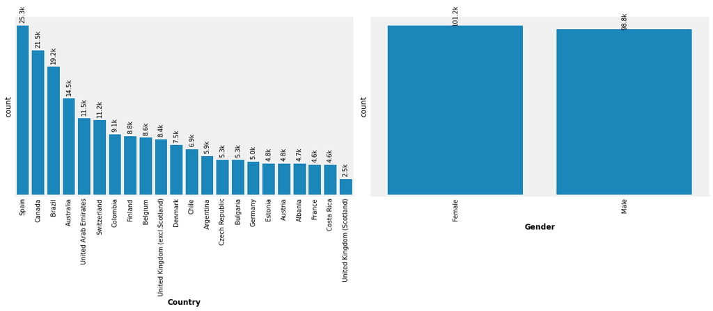

```python
count_dplot(['country', 'gender'], annotr=90)
```

Most of the students that fill out the survey come from Spain, Canada, and Brazil, with the highest female gender. Did females perform better in education than male students? Which country has the highest student performance in examinations?

### Students Primary Education

Do students have a primary education when they are young? How many years did it take to finish their primary education? What was the age of the majority of students then?

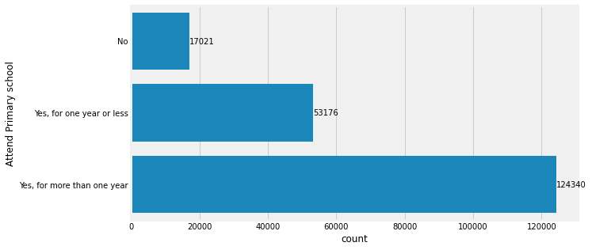

```python
count_dplot('pri_sch', usex=False, figsize=(9, 5))
plt.ylabel('Attend Primary school');
```

The majority of students attended primary school for more than one year. Does primary educational knowledge of students increase or boost their scores in international examinations?

```python
pisa_df['age_at_pri_sch'].describe()
```

```
count    184727.000000
mean          6.053138
std           1.186729
min           4.000000
25%           5.000000
50%           6.000000
75%           7.000000
max          16.000000
Name: age_at_pri_sch, dtype: float64
```

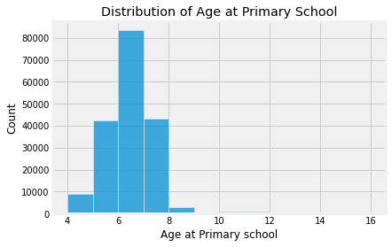

```python
bin_size = np.arange(4, 17, 1)
g = sb.histplot(data=pisa_df, x='age_at_pri_sch', bins=bin_size)
g.set_xlabel('Age at Primary school')
g.set_title('Distribution of Age at Primary School');
```

The age of most students during their primary education falls between the 4–8 age bracket, with fewer students older than that. Does early education influence student performance in education?

### Possession

Investigate the basic possessions of students. Did students possess a room, a computer, the internet, and a textbook to prepare for their education?

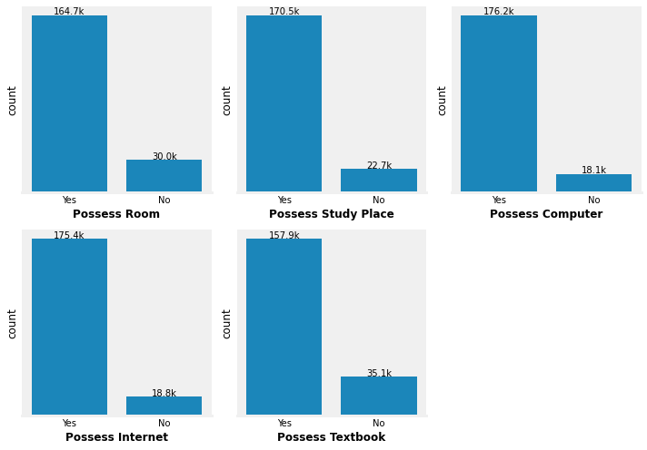

```python
count_dplot(possession, ncols=3, nrows=2, figsize=(10, 7), tick_angle=0)
```

A high number of students possessed both the internet and textbooks, but quite a few didn't. Will students without textbooks to read or the internet to learn pass their examinations?

### Parent Education Level & Earnings

Investigate the educational level of the parents. What are the most common levels of educational achievement for both parents?

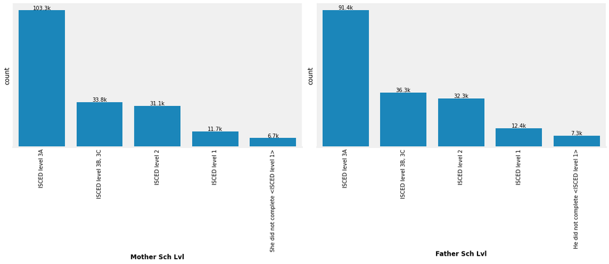

```python
count_dplot(p_schlvl_cols, annotr=0)
```

There is a right-skewed distribution in both parent educational levels, i.e., approximately half of the students in the study have a parent with some college education. How well did students that had parents with a degree perform compared to those with none? Does parent education have an influence on the performance of students?

### Parent Job Status

Since approximately half of the students' parents have a high degree, are they employed full-time or part-time?

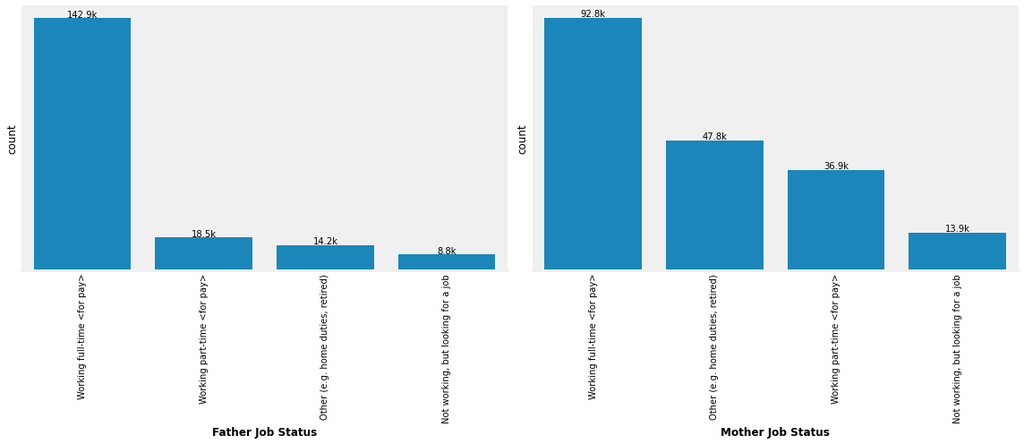

```python
count_dplot(['father_job_status', 'mother_job_status'])
```

A high number of students' parents are employed full-time, with a slight number of retirees and part-time workers. Does a student with a working full-time parent perform higher than those without?

### Distribution of Parent Earning (Pct)

```python
pisa_df[['father_earning_pct', 'mother_earning_pct']].describe()
```

|  | father_earning_pct | mother_earning_pct |
| --- | --- | --- |
| count | 169195.000000 | 157717.000000 |
| mean | 43.876301 | 45.086883 |
| std | 21.884619 | 21.995521 |
| min | 11.010000 | 11.010000 |
| 25% | 25.710000 | 25.040000 |
| 50% | 36.350000 | 43.330000 |
| 75% | 65.010000 | 65.420000 |
| max | 88.960000 | 88.960000 |

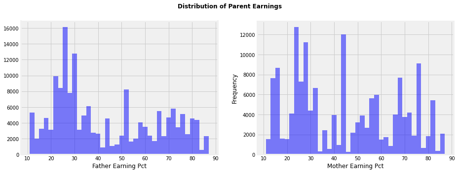

```python
bins = np.arange(11, 89, 2)
plt.figure(figsize= (14, 5))
for k, col in enumerate(['father_earning_pct', 'mother_earning_pct'], 1):
    plt.subplot(1, 2, k)
    plt.hist(pisa_df[col], bins=bins, color='b', alpha=0.5)
    plt.xlabel(col.replace("_", " ").title())
plt.ylabel('Frequency')
plt.suptitle('Distribution of Parent Earnings', fontweight='bold');
```

The distribution of parent earnings (Pct) is fairly spread out, with an approximate mean of 44 and 45, respectively, and a standard deviation of 22 (with both a minimum and maximum of 11 and 89, respectively). Does parental earning affect the performance of students in school?

### Math attributes

Are students interested in mathematics?

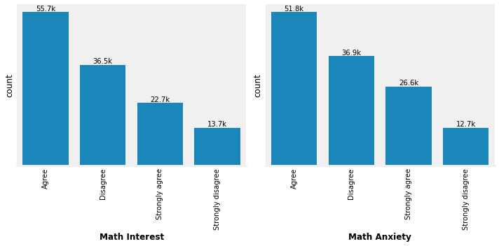

```python
count_dplot(math_related[:2], figsize=(10, 5))
```

According to the survey data, many students agree to be interested in mathematics while some disagree, so as the anxiety towards mathematics. Is it because of the teacher's behaviour or the teacher's support? Or does primary education contribute to their interest in or anxiety about mathematics?

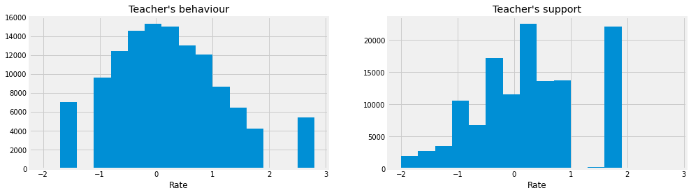

```python
bins = np.arange(-2, 3, 0.3)
plt.figure(figsize=(15, 4))
plt.subplot(1, 2, 1)
plt.hist(pisa_df['teacher_behaviour'], bins=bins)
plt.title("Teacher's behaviour")
plt.xlabel('Rate')

plt.subplot(1,2,2)
plt.hist(pisa_df['teacher_support'], bins=bins)
plt.title("Teacher's support")
plt.xlabel('Rate');
```

The distribution of the teacher's behaviour column tends to be a uni-modal distribution (i.e., between-1 and 2), while the teacher's support rate is skewed to the left. There are observable extreme values in this distribution that may warrant further investigation (negative values and some values towards 3).

### Distribution of Students performance in different subjects

Examine the distribution of student scores in different subjects. Are there any obvious differences in the distribution?

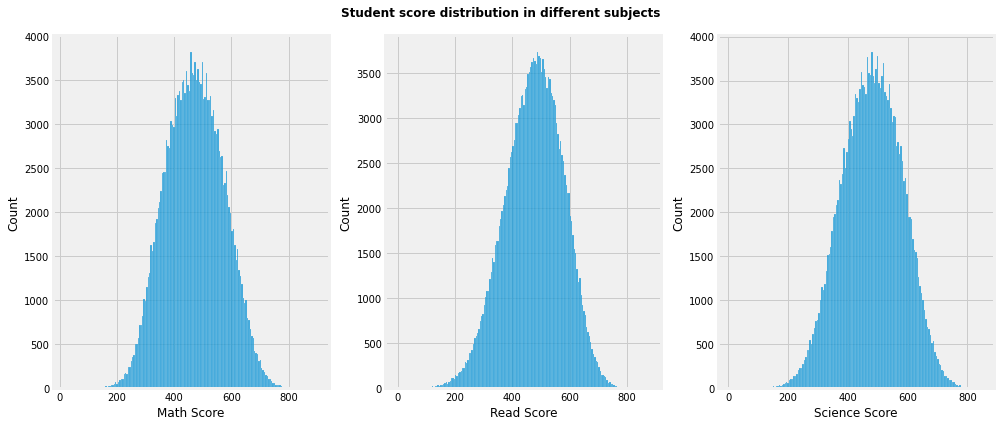

```python
def score_distribution():
    fig, axes = plt.subplots(nrows=1, ncols=3, figsize=(14, 6))
    cols = ['math_score', 'read_score', 'science_score']
    for i, ax in enumerate(axes):
        g = sb.histplot(data=pisa_df, x=cols[i], ax=ax)
        g.set_xlabel(g.get_xlabel().replace("_", " ").title())
    plt.suptitle('Student score distribution in different subjects', fontweight='bold')
    plt.tight_layout();

score_distribution()
```

The distribution of student scores is normally distributed with a mean between (470-480) and a standard deviation of (101-102). What contributes to the success of the students with the highest scores?

```python
pisa_df.iloc[:, -3:].describe().round(2)
```

|  | math_score | read_score | science_score |
| --- | --- | --- | --- |
| count | 200000.00 | 200000.00 | 200000.00 |
| mean | 471.08 | 474.88 | 480.63 |
| std | 101.45 | 102.00 | 101.77 |
| min | 19.79 | 0.08 | 6.84 |
| 25% | 397.66 | 407.01 | 409.40 |
| 50% | 470.25 | 479.13 | 481.85 |
| 75% | 543.32 | 546.91 | 553.00 |
| max | 896.80 | 875.71 | 845.90 |

### Discuss the distribution(s) of your variable(s) of interest. Were there any unusual points? Did you need to perform any transformations?

- Students that filled out the survey mostly came from Spain, Canada, and Brazil, etc., with the highest number of females. Approximately half of the students in this study have parents with more than one college degree.
- There are quite a number of students in the survey with no access to a room to study, a computer to do research on, as well as the internet and text! How will this student stand out in their examination?
- Yes, transformation is done on some columns with observations having redundant characters, leading and trailing spaces, while na values are replaced with None in some columns for consistency. Some columns with inappropriate data types were converted into their right types, and some columns which are categorical in nature were converted to categories so as to make the data frame efficient and also reduce the significant amount of memory.

### Of the features you investigated, were there any unusual distributions? Did you perform any operations on the data to tidy, adjust, or change the form of the data? If so, why did you do this?

- Only the needed data was extracted from the Pisa dataset with thousands of rows with no tidiness issues but quality.
- Many variables were converted to ordinal categorical variables. This enables the plots to show the categories in their logical order, which improves the readability of the graph and also significantly reduces the memory usage.
- Parental earnings (Pct) have a distribution with no clear shape or pattern.

## Bivariate Exploration

In this section, all pairs of variables in the data will be investigated so as to identify the relationships between them.

### Countries with highest student score

Which countries always have student mathematics scores between the 25th and 75th quantile?

```python
pisa_df['math_score'].describe()
```

```
count    200000.000000
mean        471.075796
std         101.449512
min          19.792800
25%         397.655400
50%         470.252400
75%         543.316700
max         896.798600
Name: math_score, dtype: float64
```

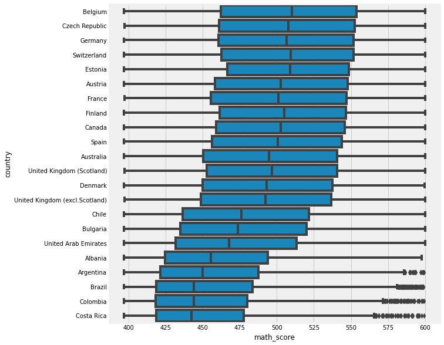

```python
mathscore_above_25_percent = pisa_df.query("math_score >= 397 & math_score <= 600")
order = mathscore_above_25_percent.groupby('country')['math_score'].quantile(.75).sort_values(ascending=False).index
fig, ax = plt.subplots(figsize=(9, 10))
sb.boxplot(data=mathscore_above_25_percent, y='country', x='math_score', order=order,color=sb.color_palette()[0]);
```

The math scores of students in Belgium, the Czech Republic, Germany, and Switzerland are always between the range of 460 and 550. What contributed to the performance of this student? Do they possess the internet, a room, a computer, and textbooks?

### Possession effect on student academic performance

How well does possession contribute to the performance of students in their academics?

```python
def possess_score(subject:str= 'math_score', data: pd.DataFrame=mathscore_above_25_percent):
    fig, axis = plt.subplots(nrows=1, ncols=4, figsize=(13, 4))
    subj_cap = subject.replace("_", " ").title()
    for index, ax in enumerate(axis):
        g = sb.barplot(data=data,
                            x=possession[index], y=subject,
                                ax=ax, color=sb.color_palette()[0])

        g.set(xlabel=g.get_xlabel().replace("_", " ").title(),
                ylabel=subj_cap)
        ax.bar_label(ax.containers[0], fmt="%.2f", label_type='edge', padding=2)
    plt.suptitle(f"{subj_cap} vs Student Possession")
    plt.tight_layout()
```

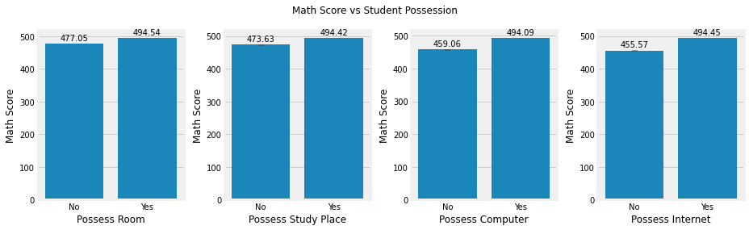

```python
possess_score()
```

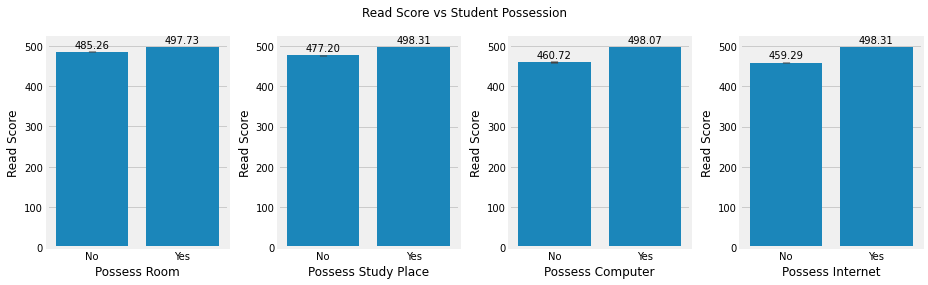

```python
possess_score('read_score')
```

Still, students with access to all these basic amenities perform excellently in reading examinations.

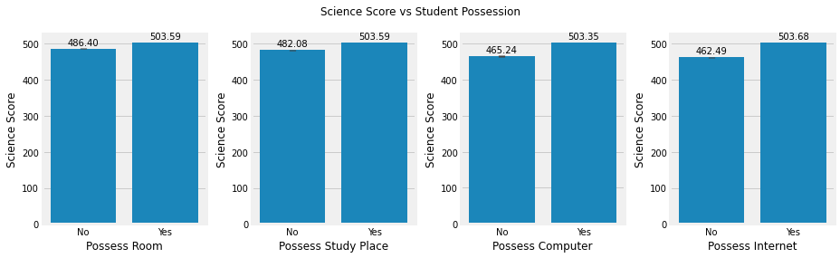

```python
possess_score('science_score')
```

Students with all the basic amenities perform more than those without in science examinations.

### Investigation on students at Belgium

Did most students with high performance in exams have access to all basic amenities such as rooms, study places, computers, and the internet?

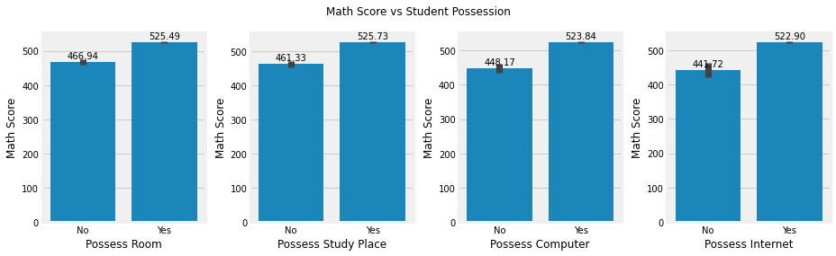

```python
possess_score(data=pisa_df.query('country=="Belgium"'))
```

Not all students with high performance in Belgium possess computers, study places, and the internet, but those with the highest scores have access.

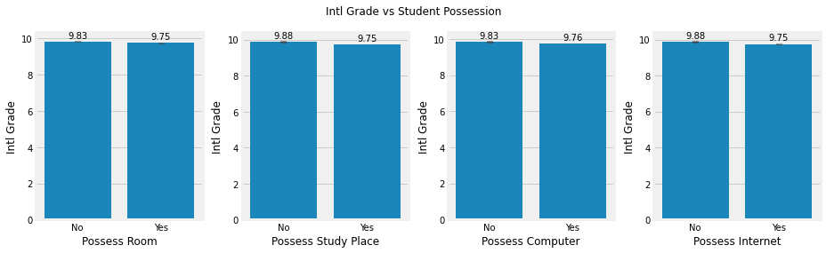

```python
possess_score('intl_grade')
```

The International Examination does not depend on whether students have access to any possessions because their general knowledge is being tested. It is safe to conclude that students that perform poorly in mathematics also have an area of strength. Are students with high performance male or female?

### Primary Education on Academic performance

What is the effect of primary education on academic performance?

```python
def primary_edu_plot(x):
    sb.violinplot(data=pisa_df, y='pri_sch', x=x, inner='quartile', palette='Greens')
    plt.ylabel('Attend Primary Education');
    plt.xlabel(x.replace('_', " ").title())
```

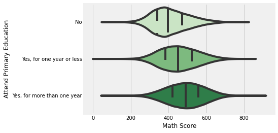

```python
primary_edu_plot('math_score')
```

There is a significant increase in the scores of students based on their experience in primary education. Primary education contributes excellently to the performance of students in mathematics.

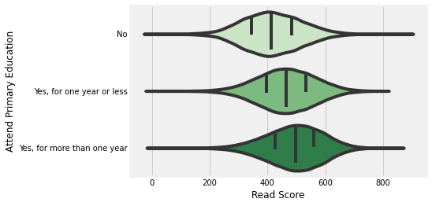

```python
primary_edu_plot('read_score')
```

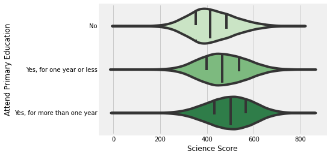

```python
primary_edu_plot('science_score')
```

As can be seen from the above visuals, primary education has a positive influence on student examination scores, with a significant positive increase from those that don't attend to those that attend more than a year.

### Early Education Influence

Does early education influence student performance in education?

```python
plt.style.use('seaborn')
def age_influence_plot(score, p='Blues_r'):
    fig, ax = plt.subplots(figsize=(15, 6))
    sb.boxenplot(data=pisa_df, x='age_at_pri_sch', y=score, palette=p, ax=ax)
    plt.xlabel('Age at Primary School')
    plt.ylabel(score.replace('_', " ").title())
    plt.title("Early education influence on Education")
```

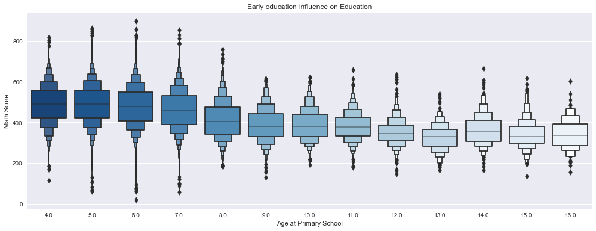

```python
age_influence_plot('math_score')
```

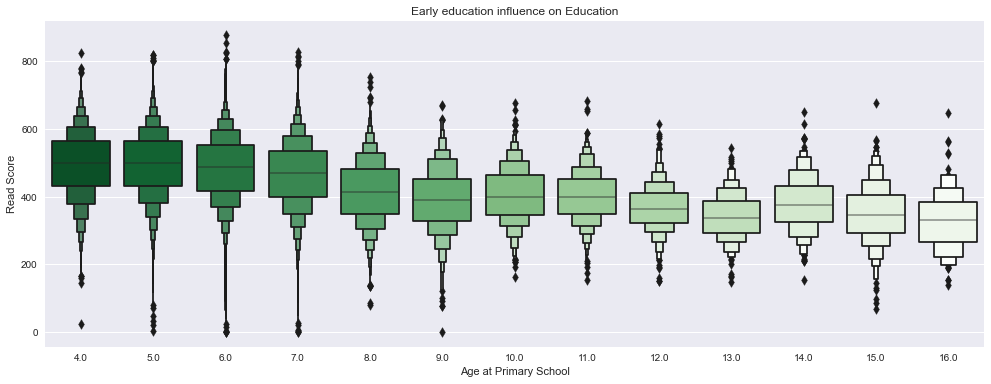

```python
age_influence_plot('read_score', p='Greens_r')
```

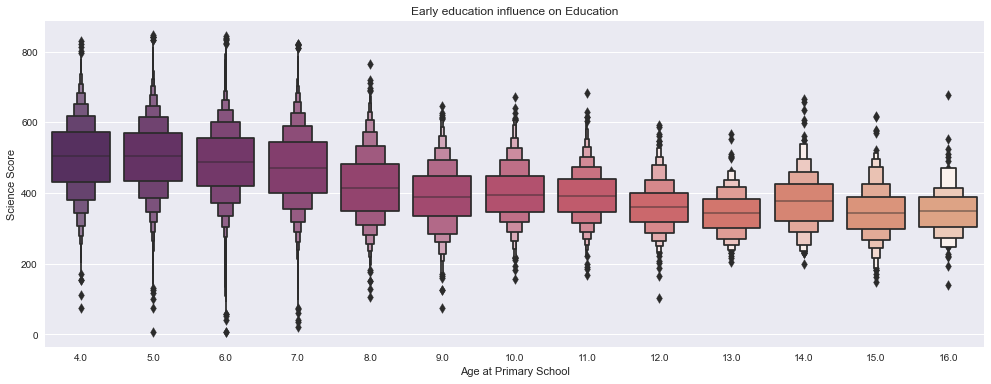

```python
age_influence_plot('science_score', p='flare_r')
```

The age at which students start their primary education has a great influence on their academic performance. As can be seen from the visuals, students that start primary education at the 4–7 age bracket perform better in their academics than those that are older before starting.

### Parent Education Influence on the Performance of the Students

How well did students that had parents with a degree perform compared to those with none? Does parent education have an influence on the performance of students? Do students from higher-education families outperform those from lower-education families?

```python
def parent_degree_inf(col):
    """
        Parent degree influence on student performance
    """
    fig, axis = plt.subplots(nrows=2, figsize=(9, 12))
    g = sb.boxplot(data=pisa_df, y=col, x='math_score', palette='viridis_r', ax=axis[0])
    g.set(xlabel=g.get_xlabel().replace("_", " ").title(),
            ylabel=g.get_ylabel().replace("_", " ").title())

    g = sb.pointplot(data=pisa_df, y=col, x='read_score', palette='viridis_r', ax=axis[1])
    g.set(xlabel=g.get_xlabel().replace("_", " ").title(),
            ylabel=g.get_ylabel().replace("_", " ").title())
    plt.suptitle('Effect of parent degree on student edcuation performance')
```

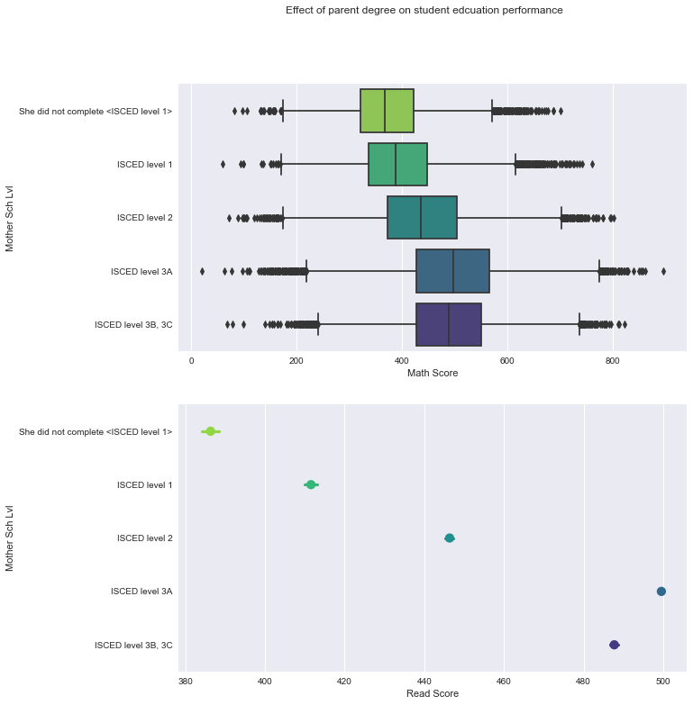

```python
parent_degree_inf('mother_sch_lvl')
```

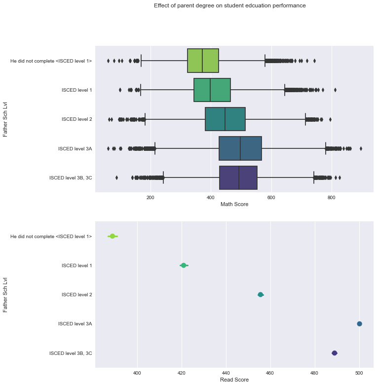

```python
parent_degree_inf('father_sch_lvl')
```

Student with highly educated parent outshines most students without educated parent.

### Parent Employment Status influence on Student Performance

How do students from low-income families perform on their exams? Does a student's parent status influence how well they perform on an exam?

```python
def parent_emp_inf():
    """
        Parent employment influence on student performance
    """
    fig, axis = plt.subplots(nrows=2, figsize=(9, 12))
    g = sb.violinplot(data=pisa_df, y='father_job_status', x='math_score', inner='quartile', palette='Blues', ax=axis[0])
    g.set(xlabel=g.get_xlabel().replace("_", " ").title(),
            ylabel=g.get_ylabel().replace("_", " ").title())

    g = sb.boxenplot(data=pisa_df, y='mother_job_status', x='read_score', palette='Greens', ax=axis[1])
    g.set(xlabel=g.get_xlabel().replace("_", " ").title(),
            ylabel=g.get_ylabel().replace("_", " ").title())
```

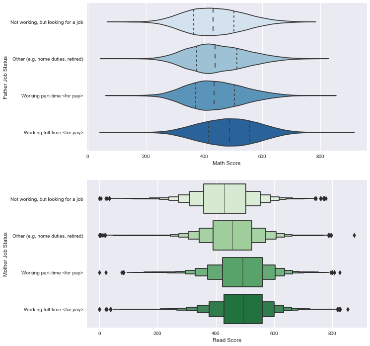

```python
parent_emp_inf()
```

Students with a parent looking for a job tend to perform quite little as compared to those with full-time working parents. It is safe to say parent occupation is related to student performance.

### Parent Earning effect on Student Education Performance

How well did students with high income parents perform as compared to low income? Are there any low-income parents whose children are performing better in examinations?

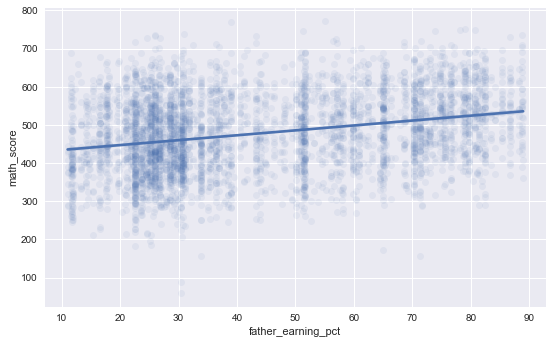

```python
sb.regplot(data=pisa_df.sample(5000), x='father_earning_pct', y='math_score', scatter_kws={'alpha': 0.07});
```

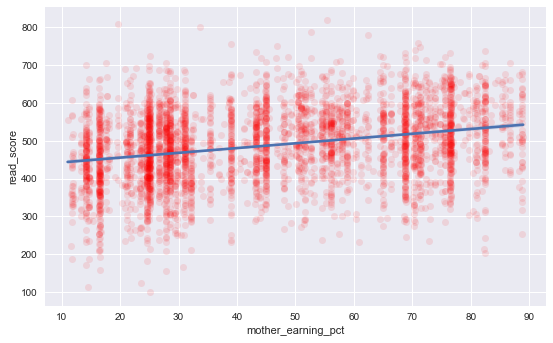

```python
sb.regplot(data=pisa_df.sample(5000), x='mother_earning_pct', y='read_score', scatter_kws={'alpha': 0.1, 'color': 'r'});
```

There is a slight upward trend between parent earnings and the performance of students in education. But this dedunction is not always the case because there are some students with low-earning parents who are intelligent enough to perform better in examinations. As can be seen from the visual, some students with low-earning parents perform quite well!

### Relationship between teacher's behaviour and student examination score

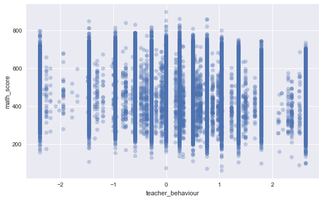

```python
sb.regplot(data=pisa_df, x='teacher_behaviour', y='math_score', fit_reg=False, scatter_kws={'alpha': 0.3});
```

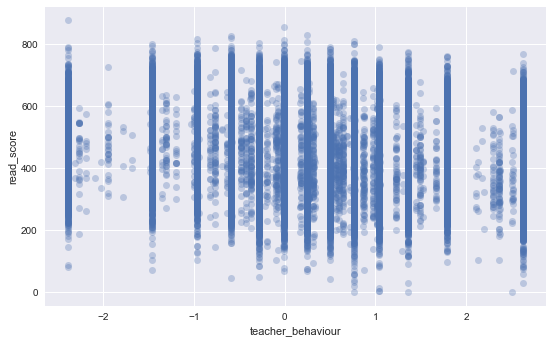

```python
sb.regplot(data=pisa_df, x='teacher_behaviour', y='read_score', fit_reg=False, scatter_kws={'alpha': 0.3});
```

Interestingly, the examination scores of students for all rated teachers are quite similar.

### Influence of students behaviour on the examination score

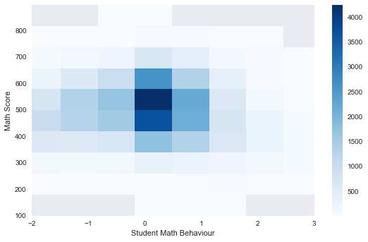

```python
plt.hist2d(data=pisa_df.dropna(), x='math_behaviour', y='math_score', cmap='Blues', cmin=0.5)
plt.xlim([-2, 3])
plt.xlabel('Student Math Behaviour')
plt.ylabel('Math Score')
plt.colorbar();
```

It is quite surprising that the behaviour of a student with the highest score in mathematics always falls between the range of 0–1.

### Gender role on Academic Performance

How does gender play a role in student examination scores? Did male students perform better in reading? Are female students good at science?

```python
def gender_effect_plot(exam_scores):
    plt.figure(figsize=(15, 7))
    for i, score in enumerate(exam_scores, 1):
        plt.subplot(1, 3, i)
        g = sb.violinplot(data=pisa_df, x='gender', y=score, inner='quartile', color='lightgreen')
        g.set(ylabel=score.replace("_", " ").title(), xlabel='Gender')
    plt.suptitle('Students performance in Examination base on their Gender')
    plt.tight_layout()
```

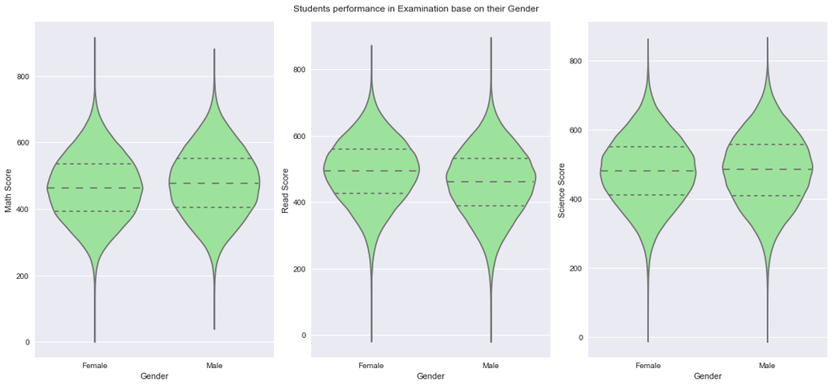

```python
# Examination score
exam_scores = ['math_score', 'read_score', 'science_score']

gender_effect_plot(exam_scores)
```

Male students seem to have higher scores in mathematics and science than females, while females perform extremely well in reading compared to males.